# Predicción de los datos en Frontur

Sandra de la Fuente

30 de mayo de 2017

En este script se desarrolla el procedimiento para obtener la respuesta a uno de los objetivos de este TFM:

- Análisis predictivo de la actividad turística en España.

# 1 Predicción de los datos

Para ello se van a utilizar las técnicas de Análisis de Series Temporales:

- Gráficos temporales.
- Series estacionarias y no estacionarias.
- Descomposición de una serie: tendencia, estacionalidad y componente irregular.
- Predicción.

Se carga el fichero fronturGLM.csv generado en la etapa anterior “Exploración de los datos”.

```r
fronturDS <- read.table("../data_exploring_03/fronturGLM.csv", header = T, sep = "," , fileEncoding = "utf-8")
head(fronturDS)
```

```
##               Id Tipo_Viajero Via_Entrada Pais Destino_CCAA Alojamiento
## 1 20170102010177            2           2   13           13           8
## 2 20170101010177            2           2   13           13           8
## 3 20170100028497            2           2   13           13           2
## 4 20170101000001            3           2   13            5           0
## 5 20170100020431            2           2   13            5           8
## 6 20170100010177            2           2   13           13           8
##   Motivo Paquete_Turistico Pernoctaciones  Viajeros Mes Anyo
## 1      4                 6              4  90.62923   1   17
## 2      4                 6              4  90.62923   1   17
## 3      1                 6              4 103.61073   1   17
## 4      1                 1              1 238.05977   1   17
## 5      1                 6              4  96.91650   1   17
## 6      4                 6              4  90.62923   1   17
```

Se realiza una revisión básica del dataset y los estadísticos de las variables para conocer de forma breve, características básicas de los datos con los que se está trabajando.

```r
str(fronturDS)
```

```
## 'data.frame':    994349 obs. of  12 variables:
##  $ Id               : Factor w/ 924141 levels "0114EVA0000376",..: 772936 765282 760574 761732 755680 749891 743179 747848 750201 751443 ...
##  $ Tipo_Viajero     : int  2 2 2 3 2 2 3 2 2 2 ...
##  $ Via_Entrada      : int  2 2 2 2 2 2 2 2 2 2 ...
##  $ Pais             : int  13 13 13 13 13 13 13 13 13 13 ...
##  $ Destino_CCAA     : int  13 13 13 5 5 13 5 4 9 9 ...
##  $ Alojamiento      : int  8 8 2 0 8 8 0 1 8 2 ...
##  $ Motivo           : int  4 4 1 1 1 4 1 1 1 1 ...
##  $ Paquete_Turistico: int  6 6 6 1 6 6 1 6 6 6 ...
##  $ Pernoctaciones   : int  4 4 4 1 4 4 1 3 5 3 ...
##  $ Viajeros         : num  90.6 90.6 103.6 238.1 96.9 ...
##  $ Mes              : int  1 1 1 1 1 1 1 1 1 1 ...
##  $ Anyo             : int  17 17 17 17 17 17 17 17 17 17 ...
```

```r
summary(fronturDS)
```

```
##               Id          Tipo_Viajero    Via_Entrada         Pais
##  20150200049950:    21   Min.   :2.000   Min.   :1.000   Min.   : 1.00
##  20151000027386:    20   1st Qu.:2.000   1st Qu.:2.000   1st Qu.: 4.00
##  20151000003194:    19   Median :2.000   Median :2.000   Median : 8.00
##  20151000004521:    19   Mean   :2.191   Mean   :2.042   Mean   : 7.72
##  20151000004528:    19   3rd Qu.:2.000   3rd Qu.:2.000   3rd Qu.:10.00
##  20151000007831:    19   Max.   :3.000   Max.   :4.000   Max.   :16.00
##  (Other)       :994232
##   Destino_CCAA    Alojamiento        Motivo      Paquete_Turistico
##  Min.   : 1.00   Min.   :0.000   Min.   :1.000   Min.   :0.000
##  1st Qu.: 4.00   1st Qu.:1.000   1st Qu.:1.000   1st Qu.:1.000
##  Median : 9.00   Median :1.000   Median :1.000   Median :6.000
##  Mean   :16.02   Mean   :2.249   Mean   :1.599   Mean   :4.288
##  3rd Qu.:10.00   3rd Qu.:2.000   3rd Qu.:1.000   3rd Qu.:6.000
##  Max.   :98.00   Max.   :9.000   Max.   :5.000   Max.   :6.000
##
##  Pernoctaciones     Viajeros              Mes              Anyo
##  Min.   :1.000   Min.   :     0.02   Min.   : 1.000   Min.   :15.00
##  1st Qu.:3.000   1st Qu.:    49.48   1st Qu.: 3.000   1st Qu.:16.00
##  Median :4.000   Median :    95.62   Median : 6.000   Median :16.00
##  Mean   :3.523   Mean   :   170.35   Mean   : 6.429   Mean   :16.05
##  3rd Qu.:4.000   3rd Qu.:   170.99   3rd Qu.:10.000   3rd Qu.:16.00
##  Max.   :6.000   Max.   :102509.74   Max.   :12.000   Max.   :17.00
##
```

Se puede apreciar que el dataset tiene 994.349 registros con 12 variables de información del turista:

- id del turista.
- tipo del turista.
- via de entrada del turista.
- pais del turista.
- destino del turista.
- alojamiento durante el viaje.
- motivo del viaje.
- paquete turistico contratado.
- número de pernoctaciones.
- viajeros
- mes del viaje.
- año del viaje.

# 2 Formateo de los datos

Se crea una variables nueva con la fecha resultado de la unión del mes y año, como no está informado el día, se define para todas las fechas el día 01.

```r
fronturDS$Viajeros<-as.numeric(fronturDS$Viajeros)

fronturDS$Tipo_Viajero<-as.factor(fronturDS$Tipo_Viajero)
fronturDS$Via_Entrada<-as.factor(fronturDS$Via_Entrada)
fronturDS$Pais<-as.factor(fronturDS$Pais)
fronturDS$Destino_CCAA<-as.factor(fronturDS$Destino_CCAA)
fronturDS$Alojamiento<-as.factor(fronturDS$Alojamiento)
fronturDS$Motivo<-as.factor(fronturDS$Motivo)
fronturDS$Pernoctaciones<-as.factor(fronturDS$Pernoctaciones)
fronturDS$Paquete_Turistico<-as.factor(fronturDS$Paquete_Turistico)

fronturDS$Anyo <- gsub(" ", "",paste("20",fronturDS$Anyo))

fronturDS$Fecha <- as.Date(paste("01", as.numeric(fronturDS$Mes),
                                as.numeric(fronturDS$Anyo),
                               sep="-"),format = "%d-%m-%Y")

fronturDS$Mes <- as.numeric(fronturDS$Mes)
fronturDS$Anyo <- as.numeric(fronturDS$Anyo)
```

De nuevo se realiza la revisión del dataset con las modificaciones realizadas en las variables y los estadísticos.

```r
nrow(fronturDS)
```

```
## [1] 994349
```

```r
ncol(fronturDS)
```

```
## [1] 13
```

```r
str(fronturDS)
```

```
## 'data.frame':    994349 obs. of  13 variables:
##  $ Id               : Factor w/ 924141 levels "0114EVA0000376",..: 772936 765282 760574 761732 755680 749891 743179 747848 750201 751443 ...
##  $ Tipo_Viajero     : Factor w/ 2 levels "2","3": 1 1 1 2 1 1 2 1 1 1 ...
##  $ Via_Entrada      : Factor w/ 4 levels "1","2","3","4": 2 2 2 2 2 2 2 2 2 2 ...
##  $ Pais             : Factor w/ 15 levels "1","2","4","5",..: 12 12 12 12 12 12 12 12 12 12 ...
##  $ Destino_CCAA     : Factor w/ 19 levels "1","2","3","4",..: 13 13 13 5 5 13 5 4 9 9 ...
##  $ Alojamiento      : Factor w/ 10 levels "0","1","2","3",..: 9 9 3 1 9 9 1 2 9 3 ...
##  $ Motivo           : Factor w/ 5 levels "1","2","3","4",..: 4 4 1 1 1 4 1 1 1 1 ...
##  $ Paquete_Turistico: Factor w/ 3 levels "0","1","6": 3 3 3 2 3 3 2 3 3 3 ...
##  $ Pernoctaciones   : Factor w/ 6 levels "1","2","3","4",..: 4 4 4 1 4 4 1 3 5 3 ...
##  $ Viajeros         : num  90.6 90.6 103.6 238.1 96.9 ...
##  $ Mes              : num  1 1 1 1 1 1 1 1 1 1 ...
##  $ Anyo             : num  2017 2017 2017 2017 2017 ...
##  $ Fecha            : Date, format: "2017-01-01" "2017-01-01" ...
```

# 3 Análisis de Series Temporales

Seleccionamos las columnas que se van a utilizar para la Serie Temporal (Viajeros, Mes y AÑO).

Pasos a realizar: - Se realiza una agrupación por mes y año de la suma de los Viajeros. - Se ordena los resultados por año. - Se genera la serie temporal definiendo el comienzo 2015-10 y periodicidad 12 meses. - Se dibuja la serie temporal

```r
fronturST = fronturDS[c(10,11,12,13)]

range(fronturST$Fecha)
```

```
## [1] "2015-10-01" "2017-04-01"
```

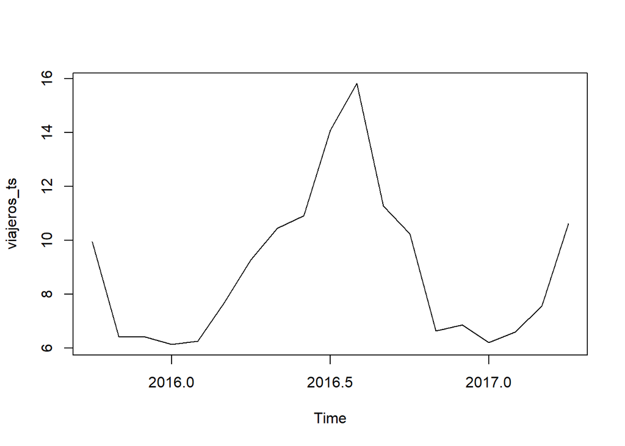

```r
## rango de fechas "2015-10-01" "2017-04-01"

#agrupo por mes y año

viajeros_tmp <-fronturST  %>%  group_by(Mes,Anyo)  %>% summarise(total = sum(Viajeros))
viajeros_tmp <- arrange(viajeros_tmp, Anyo)

viajeros_tmp$Mes<-NULL
viajeros_tmp$Anyo<-NULL

viajeros_tmp$total<-viajeros_tmp$total/1e+6

viajeros_ts = ts(viajeros_tmp, start = c(2015,10), frequency = 12)

ts.plot(viajeros_ts)
```

Se considera que los datos no presentan forma creciente(tendencia) pero por el contrario si existe influencia de ciertos periodos de cualquier unidad de tiempo (estacionalidad). No aparecen outliers (observaciones extrañas o discordantes).

# 4 Predicción de la Serie Temporal

Se realiza la predicción de la Serie Temporal utilizando el Modelo ARIMA, para realizar predicciones se usa predict().

No se ha usado forecast() porque daba error por no tener más de dos periodos.

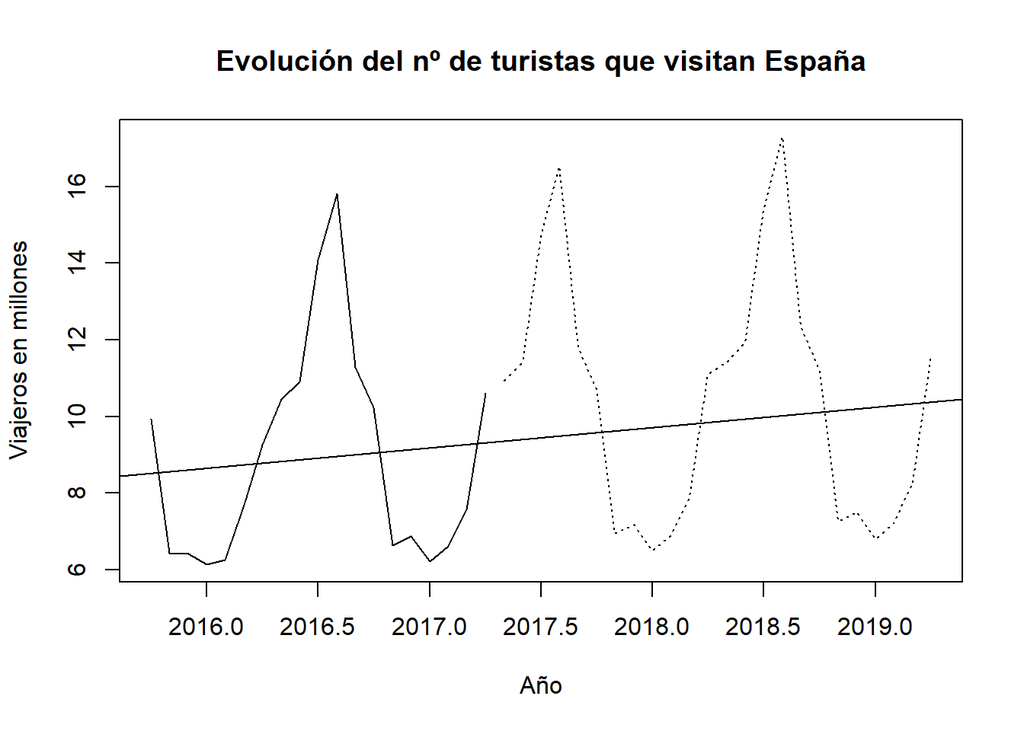

```r
logviajeros_ts <- log(viajeros_ts)

ajuste <- arima(logviajeros_ts, c(0, 1, 1), seasonal = list(order = c(0, 1, 1), period = 12))

pred <- predict(ajuste, n.ahead =24) #predicción para los dos proximos año


ts.plot(viajeros_ts,2.718^pred$pred, xlab="Año", ylab="Viajeros en millones", main = "Evolución del nº de turistas que visitan España", lty = c(1,3))
abline(reg=lm(viajeros_ts~time(viajeros_ts)))
```

La serie es obviamente no estacionaria y la serie diferenciada tampoco, como puede observarse en el siguiente gráfico:

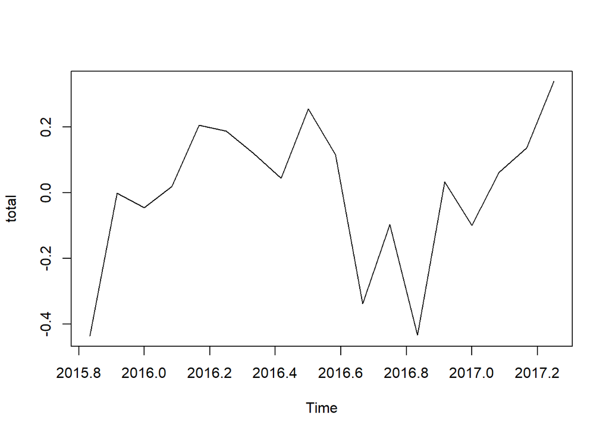

```r
dms=diff(logviajeros_ts)
plot(dms)
```

Los correlogramas para la serie diferenciada:

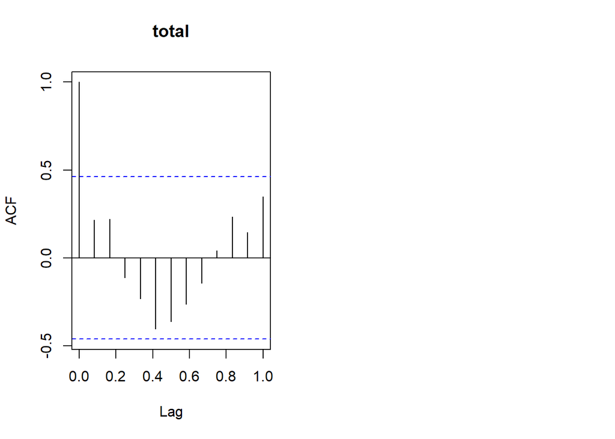

```r
par(mfrow=c(1,2))
acf(dms)
```

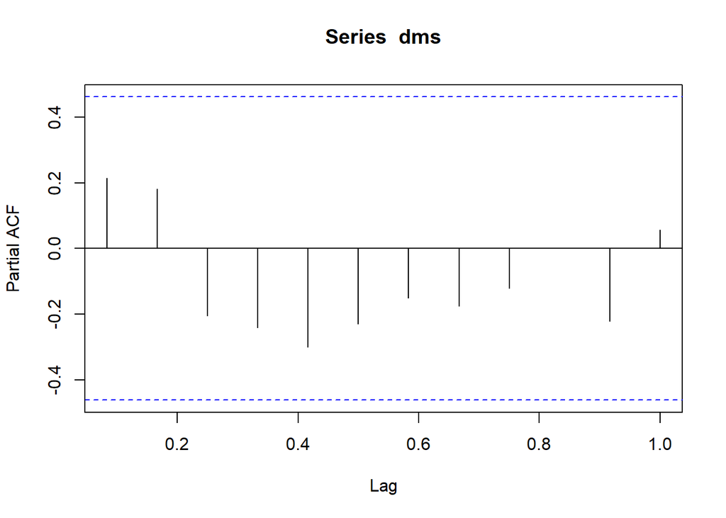

```r
#Graficamos su correlograma


pacf(dms)
```

Gráfico para la predicción de 5 años:

```r
mean(viajeros_ts)
```

```
## [1] 8.915009
```

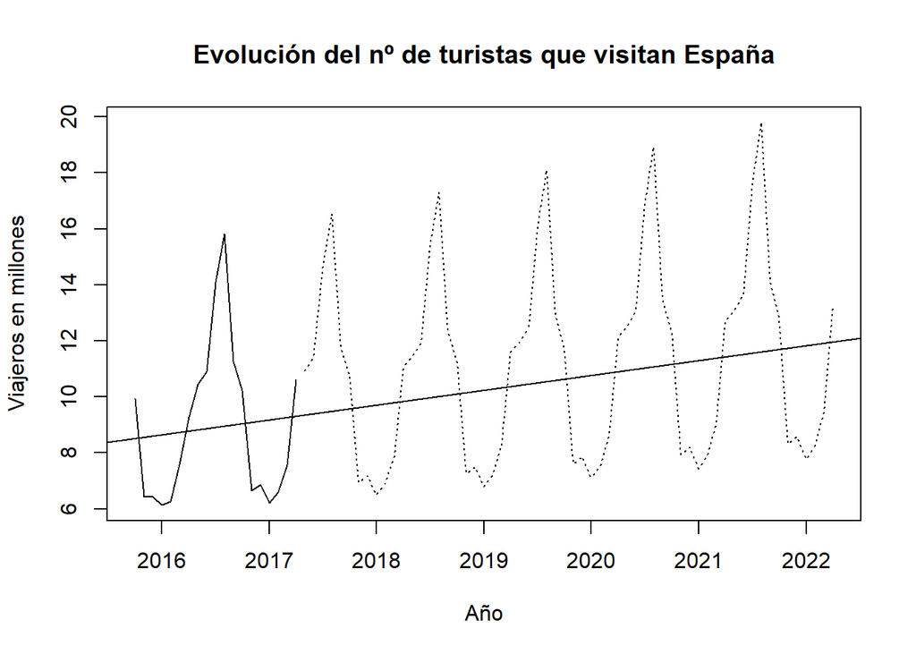

```r
ajuste <- arima(logviajeros_ts, c(0, 1, 1), seasonal = list(order = c(0, 1, 1), period = 12))

pred <- predict(ajuste, n.ahead =5* 12 ) #predicción para los dos proximos año


ts.plot(viajeros_ts,2.718^pred$pred, xlab="Año", ylab="Viajeros en millones", main = "Evolución del nº de turistas que visitan España", lty = c(1,3))
abline(reg=lm(viajeros_ts~time(viajeros_ts)))
```

# 5 Conclusiones

Para conseguir uno de los objetivos del TFM, realizar un análisis predictivo de la actividad turística en España, para predecir el número de turistas que decidan viajar a un lugar determinado en España, se ha utilizado el método de predicción de Serie Temporal.

Se realiza la predicción de la Serie Temporal utilizando el Modelo ARIMA, para realizar predicciones se usa predict(). No se ha usado forecast() porque se obtiene un error, por no tener más de dos periodos. Se observa una tendencia a incrementar el número de viajeros que visitarán España, sobre todo durante la estacionalidad del verano.